# As-a-Statistician-Mixed Model

## Random Slope and Intercept Model

**This structure assumes that the errors are independent, and thus is termed an independent structure.**

$$\Sigma =
\left[
\begin{array}{ccc}
\sigma_1^2 & 0 & 0 \\
0 & \sigma_2^2 & 0 \\
0 & 0 & \sigma_3^2 \\
\end{array}\right]$$

### Model Introduction

Suppose data are collected longitudinally at times $t_{1}, \ldots, t_{p} .$ For each individual $i, i=1, \ldots, n$, at time $t_{j}, j=1, \ldots, p$, the observations are $x_{1 i j}, \ldots, x_{k i j}, y_{i j}$ The random slope and intercept model is defined as
$$y_{i j}=\beta_{0}+\beta_{1} x_{1 i j}+\cdots+\beta_{k} x_{k i j}+\beta_{k+1} t_{j}+u_{1 i}+u_{2 i} t_{j}+\varepsilon_{i j}$$
where

- $u_{1 i}$ ’s are independent $\mathcal{N}\left(0, \sigma_{u_{1}}^{2}\right)$ random intercepts,
- $u_{2 i}$ ’s are independent $\mathcal{N}\left(0, \sigma_{u_{2}}^{2}\right)$ random slopes,
- and $\varepsilon_{i j}$ ’s are independent $\mathcal{N}\left(0, \sigma^{2}\right)$ errors that are also independent of $u_{1 i}$ ’s and $u_{2 i}$ ’s

It is assumed that $\operatorname{Cov}\left(u_{1 i}, u_{2 i}\right)=\sigma_{u_{1} u_{2}}$, and $\operatorname{Cov}\left(u_{1 i}, u_{2 i^{\prime}}\right)=0$ for $i \neq i^{\prime}$ 预测变量 $x_{1}, \ldots, x_{k}$ 具有固定影响, 而随机截距 $u_{1}$ 和斜率 $u_{2}$ 具有随机影响。同样值得注意的是, 预测 变量 $x 1, \ldots, x k$ 可能会随时间变化。 $\operatorname{Cov}\left(y_{i j}, y_{i^{\prime} j^{\prime}}\right)=0, i \neq i^{\prime}$, 意味着在任何时间点, 针对不同个人的响应都是不相关的。还可以表明, 同一个人在不同时间点之间的响应可能是相关的, 因为 $\operatorname{Cov}\left(y_{i j}, y_{i j^{\prime}}\right)=\sigma_{u_{1}}^{2}+\sigma_{u_{1} u_{2}}\left(t_{j}+t_{j^{\prime}}\right)+\sigma_{u_{2}}^{2} t_{j} t_{j^{\prime}}$ for $j \neq j^{\prime}$. 此外, 可以验证响应变量 $y_{i j}$ 与均值呈正态分布 $y_{i j}$
$$\mathbb{E}(y)=\beta_{0}+\beta_{1} x_{1}+\cdots+\beta_{k} x_{k}+\beta_{k+1} t$$
$$\operatorname{Var}\left(y_{i j}\right)=\sigma_{u_{1}}^{2}+2 \sigma_{u_{1} u_{2}} t_{j}+\sigma_{u_{2}}^{2} t_{j}^{2}+\sigma^{2}$$

### SAS Implementation

```
## short-and-wide form to the long-form data set
data cholesterol;
input id gender$ age LDL0 LDL6 LDL9 LDL24 @@;
cards;
1 M 50 73 71 80 85 2 F 72 174 164 139 112
3 M 46 85 86 82 90 4 F 71 172 150 139 127
5 F 75 186 177 153 145 6 F 68 184 169 153 138
7 F 63 196 188 163 155 8 M 73 137 137 132 104
9 M 59 135 120 106 106 10 M 60 111 110 100 76
11 F 59 127 126 106 99 12 M 46 88 87 84 80
13 F 67 176 150 156 153 14 F 52 155 135 128 120
15 M 65 142 117 114 97 16 F 75 158 143 145 135
17 F 57 148 131 138 102 18 M 58 125 111 118 124
19 M 48 76 65 94 98 20 M 47 116 108 94 107
21 F 53 191 185 162 113 22 F 73 167 165 162 140
23 M 62 109 104 93 94 24 F 77 167 164 155 155
25 M 55 103 94 75 78 26 F 74 122 126 105 111
27 F 79 203 204 178 145
;

data longform;
set cholesterol;
array m[4] (0 6 9 24);
array c[4] LDL0 LDL6 LDL9 LDL24;
do i=1 to 4;
month=m[i];
LDL=c[i];
output;
end;
keep id gender age month LDL;
run;

## construct a histogram with fitted bell-shaped curve and
   conduct normality testing
proc univariate data=longform;
var LDL;
histogram LDL/normal;
run;

## fit a random slope and intercept model
proc mixed data=covtest:
class gender;
model LDL=gender age month/solution;
random intercept month/subject=id type=un;
run;

Covariance Parameter Estimates
Cov Parm Estimate Pr Z
UN(1,1) 520.17 0.0013
UN(2,1) -16.3953 0.0087
UN(2,2) 0.7846 0.0028
Residual 69.8556 <.0001
```

- The outpm= produces prediction of the response $y$ for each row in the data set. If a new prediction is desired, the case must be added to the data set.
- Specification of type=un, an unstructured type of variance-covariance matrix, requests an estimate of the covariance $\sigma_{u_{1} u_{2}}$.
- In the output, the estimators of $\sigma_{u_{1}}^{2}, \sigma_{u_{1} u_{2}}, \sigma_{u_{2}}^{2}$, and $\sigma^{2}$ are termed UN $(1,1)$, UN $(2,1)$, UN $(2,2)$ and Residual, respectively.

### R Implementation

#### Model with one random intercept effekct

```r
library("lme4")
library("lmerTest")
library("dplyr")
load("./01_Datasets/gpa.RData")

## Standard regression
gpa_lm = lm(gpa ~ occasion, data = gpa)
summary(gpa_lm)
```

```
##
## Call:
## lm(formula = gpa ~ occasion, data = gpa)
##
## Residuals:
##      Min       1Q   Median       3Q      Max
## -0.90553 -0.22447 -0.01184  0.26921  1.19447
##
## Coefficients:
##             Estimate Std. Error t value Pr(>|t|)
## (Intercept) 2.599214   0.017846  145.65   <2e-16 ***
## occasion    0.106314   0.005894   18.04   <2e-16 ***
## ---
## Signif. codes:  0 '***' 0.001 '**' 0.01 '*' 0.05 '.' 0.1 ' ' 1
##
## Residual standard error: 0.3487 on 1198 degrees of freedom
## Multiple R-squared:  0.2136, Adjusted R-squared:  0.2129
## F-statistic: 325.3 on 1 and 1198 DF,  p-value: < 2.2e-16
```

```r
## Run a mixed model, taking into account the specific effects of the students
## (1 | student) means that the intercept allowed to be expressed by 1 varies from student to student
gpa_mixed = lmer(gpa ~ occasion + (1 | student), data = gpa)
summary(gpa_mixed)
```

```
## Linear mixed model fit by REML. t-tests use Satterthwaite's method [
## lmerModLmerTest]
## Formula: gpa ~ occasion + (1 | student)
##    Data: gpa
##
## REML criterion at convergence: 408.9
##
## Scaled residuals:
##     Min      1Q  Median      3Q     Max
## -3.6169 -0.6373 -0.0004  0.6361  2.8310
##
## Random effects:
##  Groups   Name        Variance Std.Dev.
##  student  (Intercept) 0.06372  0.2524
##  Residual             0.05809  0.2410
## Number of obs: 1200, groups:  student, 200
##
## Fixed effects:
##              Estimate Std. Error        df t value Pr(>|t|)
## (Intercept) 2.599e+00  2.170e-02 3.223e+02   119.8   <2e-16 ***
## occasion    1.063e-01  4.074e-03 9.990e+02    26.1   <2e-16 ***
## ---
## Signif. codes:  0 '***' 0.001 '**' 0.01 '*' 0.05 '.' 0.1 ' ' 1
##
## Correlation of Fixed Effects:
##          (Intr)
## occasion -0.469
```

```r
## Another way to interpret the variance output is to record the student variance as a percentage of the total variance, which is 0.064 / 0.122 = 52%.
## This is also called intra-class correlation because it is also an estimate of intra-cluster correlation

## Profile confidence intervals
confint(gpa_mixed)
```

```
##                  2.5 %    97.5 %
## .sig01      0.22517423 0.2824604
## .sigma      0.23071113 0.2518510
## (Intercept) 2.55665145 2.6417771
## occasion    0.09832589 0.1143027
```

```r
## 随机效果和随机拦截（即拦截+随机效果）
ranef(gpa_mixed)$student %>% head(5)
```

|  | (Intercept) |
| --- | --- |
| 1 | -0.07089492 |
| 2 | -0.21557844 |
| 3 | 0.08825694 |
| 4 | -0.18664174 |
| 5 | 0.03038354 |

```r
## 不允许场合发生变化，对所有学生而言，这是一个固定的影响
coef(gpa_mixed)$student %>% head(5)
```

|  | (Intercept) | occasion |
| --- | --- | --- |
| 1 | 2.528319 | 0.1063143 |
| 2 | 2.383636 | 0.1063143 |
| 3 | 2.687471 | 0.1063143 |
| 4 | 2.412573 | 0.1063143 |
| 5 | 2.629598 | 0.1063143 |

```r
## 这些影响非常感兴趣，并希望对它们产生某种不确定性
library(merTools)
predictInterval(gpa_mixed)   # 用于各种模型预测，可能带有新数据
```

| fit | upr | lwr |
| --- | --- | --- |
| 2.530467 | 2.867398 | 2.213945 |
| 2.633571 | 2.974854 | 2.296647 |
| 2.758187 | 3.081019 | 2.412629 |
| 2.844303 | 3.160178 | 2.513994 |
| 2.949384 | 3.271951 | 2.608081 |
| 3.062384 | 3.389978 | 2.722255 |
| 2.397308 | 2.740019 | 2.080944 |
| 2.485337 | 2.813668 | 2.150641 |
| 2.601794 | 2.928855 | 2.289820 |
| 2.698312 | 3.025207 | 2.369459 |

[output cut: 1190 more lines]

```r
REsim(gpa_mixed)             # 随机效应估计的均值，中位数和标准差
```

| groupFctr | groupID | term | mean | median | sd |
| --- | --- | --- | --- | --- | --- |
| student | 1 | (Intercept) | -0.0672845089 | -0.072180699 | 0.09586463 |
| student | 2 | (Intercept) | -0.2190276037 | -0.216334123 | 0.08957304 |
| student | 3 | (Intercept) | 0.0822049915 | 0.090209152 | 0.09765920 |
| student | 4 | (Intercept) | -0.1900843509 | -0.193327013 | 0.09316535 |
| student | 5 | (Intercept) | 0.0289345098 | 0.027340352 | 0.09053222 |
| student | 6 | (Intercept) | -0.2977200524 | -0.301681262 | 0.08732862 |
| student | 7 | (Intercept) | -0.1338758272 | -0.143920252 | 0.09328067 |
| student | 8 | (Intercept) | 0.2270328175 | 0.229690438 | 0.08916511 |
| student | 9 | (Intercept) | 0.1010598598 | 0.097695704 | 0.09309395 |
| student | 10 | (Intercept) | 0.0146596574 | 0.013458314 | 0.09299815 |

[output cut: 190 more lines]

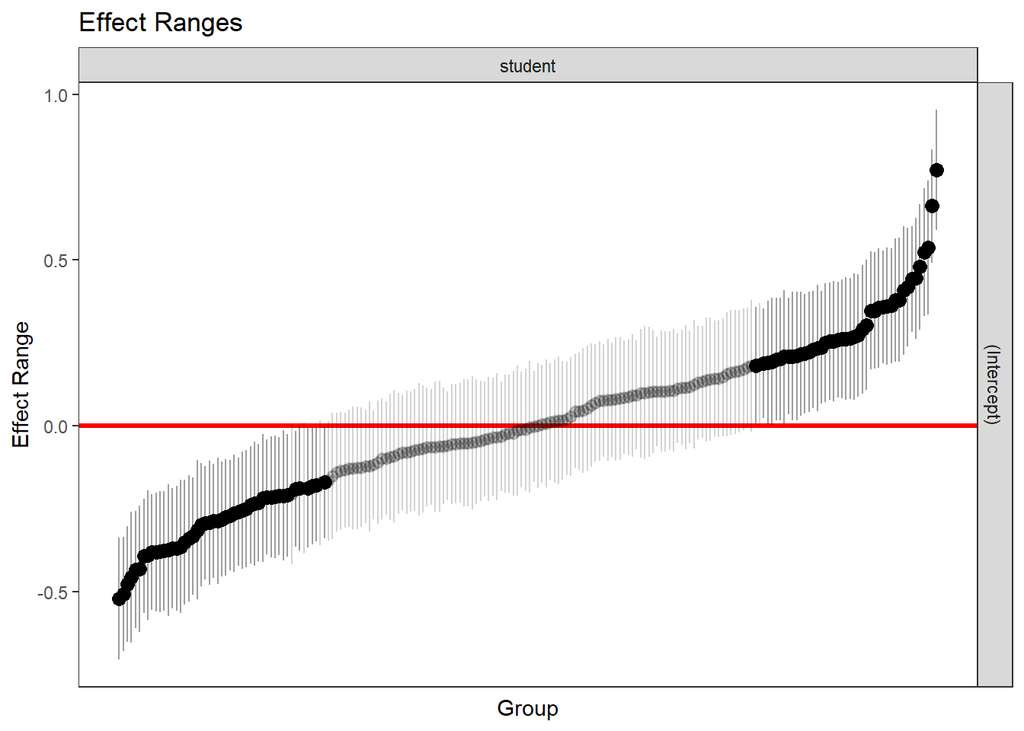

```r
plotREsim(REsim(gpa_mixed))  # 绘制间隔估计
```

```r
## 预测 不要使用随机效应re.form = NA
predict(gpa_mixed, re.form=NA) %>% head()
```

```
##        1        2        3        4        5        6
## 2.599214 2.705529 2.811843 2.918157 3.024471 3.130786
```

```r
## R outputs AIC and BIC values automatically. The AICC value has to be computed as
## AICC <- -2*logLik(gpa_mixed)+2*p*n/(n-p-1)
```

#### Model with random intercept and slpoe effects

```r
gpa_mixed =  lmer(gpa ~ occasion + (1 + occasion | student), data = gpa)
summary(gpa_mixed)
```

```
## Linear mixed model fit by REML. t-tests use Satterthwaite's method [
## lmerModLmerTest]
## Formula: gpa ~ occasion + (1 + occasion | student)
##    Data: gpa
##
## REML criterion at convergence: 261
##
## Scaled residuals:
##     Min      1Q  Median      3Q     Max
## -3.2695 -0.5377 -0.0128  0.5326  3.1939
##
## Random effects:
##  Groups   Name        Variance Std.Dev. Corr
##  student  (Intercept) 0.045193 0.21259
##           occasion    0.004504 0.06711  -0.10
##  Residual             0.042388 0.20588
## Number of obs: 1200, groups:  student, 200
##
## Fixed effects:
##              Estimate Std. Error        df t value Pr(>|t|)
## (Intercept) 2.599e+00  1.836e-02 1.990e+02  141.59   <2e-16 ***
## occasion    1.063e-01  5.885e-03 1.990e+02   18.07   <2e-16 ***
## ---
## Signif. codes:  0 '***' 0.001 '**' 0.01 '*' 0.05 '.' 0.1 ' ' 1
##
## Correlation of Fixed Effects:
##          (Intr)
## occasion -0.345
```

## Covariance Structure

### Model Introduction

In the random slope and intercept model introduced before, the variance-covariance matrix for the error terms has a diagonal structure. It is of the form $\sigma^{2} \mathbb{I}$, where $\mathbb{I}$ denotes a $n p \times n p$ identity matrix, with ones on the main diagonal and zeros everywhere else. This structure assumes that the errors are independent, and thus is termed an independent structure.

The random slope and intercept models with other structures for the variance-covariance matrix of the error terms can be considered. The most general is an unstructured one with an $n p \times n p$ block-diagonal matrix with $n$ identical blocks of size $p \times p$ of the form:
$$\left[\begin{array}{ccccc}
\sigma_{1}^{2} & \sigma_{12} & \sigma_{13} & \ldots & \sigma_{1 p} \\
\sigma_{12} & \sigma_{2}^{2} & \sigma_{23} & \ldots & \sigma_{2 p} \\
\sigma_{13} & \sigma_{23} & \sigma_{3}^{2} & \ldots & \sigma_{3 p} \\
\ldots & \ldots & \ldots & \ldots & \ldots \\
\sigma_{1 p} & \sigma_{2 p} & \sigma_{3 p} & \ldots & \sigma_{p}^{2}
\end{array}\right]$$

- 如果数据集的大小允许，则应使用带有误差项的非结构化方差协方差矩阵的模型。 该模型不对结构进行任何假设，并允许每个参数的估计取其自身的值。
- 如果数据集的大小太小而无法适合一般的非结构化方差协方差矩阵，则可以尝试几种稀疏但有意义的结构。

The first model has the blocks in the variance-covariance matrix that have constant values on each of the descending diagonals, that is, the matrix has the form:

$$\left[\begin{array}{ccccc}
\sigma^{2} & \sigma_{1} & \sigma_{2} & \ldots & \sigma_{p-1} \\
\sigma_{1} & \sigma^{2} & \sigma_{1} & \ldots & \sigma_{p-2} \\
\sigma_{2} & \sigma_{1} & \sigma^{2} & \ldots & \sigma_{p-3} \\
\ldots & \ldots & \ldots & \ldots & \ldots \\
\sigma_{p-1} & \sigma_{p-2} & \sigma_{p-3} & \ldots & \sigma^{2}
\end{array}\right]$$

Using this structure implies that observations that are the same number of time points apart are equally correlated. There are a total of $p$ unknown parameters $\sigma^{2}, \sigma_{1}, \ldots, \sigma_{p-1} .$ This model is said to have the Toeplitz covariance structure, which is sometimes referred to as an autoregressive-moving average $\operatorname{ARMA}(1,1)$ structure.

Another model with useful structure of the variance-covariance matrix relies on the fact that typically as time goes on, observations become less correlated with the earlier ones. In this model, each block in the variance-covariance matrix has $\sigma^{2} \rho^{\left|t_{i}-t_{j}\right|}$ in the $i j$ -th cell, $i, j=1, \ldots, p$, that is, it looks like this:

$$\sigma^{2}\left[\begin{array}{ccccc}
1 & \rho^{\left|t_{1}-t_{2}\right|} & \rho^{\left|t_{1}-t_{3}\right|} & \ldots & \rho^{\left|t_{1}-t_{p}\right|} \\
\rho^{\left|t_{1}-t_{2}\right|} & 1 & \rho^{\left|t_{2}-t_{3}\right|} & \ldots & \rho^{\left|t_{2}-t_{p}\right|} \\
\rho^{\left|t_{1}-t_{3}\right|} & \rho^{\left|t_{2}-t_{3}\right|} & 1 & \ldots & \rho^{\left|t_{3}-t_{p}\right|} \\
\ldots & \ldots & \ldots & \ldots & \ldots \\
\rho^{\left|t_{1}-t_{p}\right|} & \rho^{\left|t_{2}-t_{p}\right|} & \rho^{\left|t_{3}-t_{p}\right|} & \ldots & 1
\end{array}\right]$$
Here $\sigma^{2}$ and $\rho$ are the unknown constants, $|\rho|<1$. Note that in this matrix the entries decrease as the distance between times $t_{i}$ and $t_{j}$ increases. 这种形式的矩阵称为空间幕矩 阵，因此该模型具有误差项的空间幕方差-协方差结构。

$$\sigma^{2}\left[\begin{array}{ccccc}
1 & \rho & \rho^{2} & \ldots & \rho^{p-1} \\
\rho & 1 & \rho & \ldots & \rho^{p-2} \\
\rho^{2} & \rho & 1 & \ldots & \rho^{p-3} \\
\ldots & \ldots & \ldots & \ldots & \ldots \\
\rho^{p-1} & \rho^{p-2} & \rho^{p-3} & \ldots & 1
\end{array}\right]$$
This model is said to have an autoregressive variance-covariance structure of the error terms, referring to an AR(1) model, an autoregressive time series model with lag one that has the same covariance structure. Note that the autoregressive matrix is a special case of both Toeplitz and spatial power matrices.

The last model that we introduce here is the model with compound symmetric (or exchangeable) variance-covariance matrix of the error terms. In this matrix, all variances are assumed to be equal to $\sigma^{2}$, and all correlations are assumed to be equal to $\rho$. That is, the matrix has the form:

$$\sigma^{2}\left[\begin{array}{ccccc}
1 & \rho & \rho & \ldots & \rho \\
\rho & 1 & \rho & \ldots & \rho \\
\rho & \rho & 1 & \ldots & \rho \\
\ldots & \ldots & \ldots & \ldots & \ldots \\
\rho & \rho & \rho & \ldots & 1
\end{array}\right]$$
这种方差-协方差结构更适合在各种治疗条件下 (而不是纵向) 进行重复测量的情况, 因为假定所 有观察值均具有同等相关性

### SAS Implementation

`repeated / subject=id name type=covtype name r;`

- Covariance structures in the option type= are un (unstructured), toep (Toeplitz), sp(pow)(time_name) (spatial power), ar(1) (autoregressive), or cs (compound symmetric).
- By specifying the option $r$ we request that SAS outputs an estimated individual block of the variance-covariance matrix of the error terms, labeling it Estimated R Matrix for Subject 1 .
- Estimated correlation coefficient $\rho$ in the output is labeled SP(POW) (spatial power), AR (1) (autoregressive), or CS (compound symmetric).

```
/*fitting random slope and intercept model with
  unstructured covariance matrix of error terms*/
proc mixed covtest;
    class gender;
    model LDL=gender age month/solution;
    random intercept month/subject=id type=un;
    repeated/subject=id type=un r;
run;

/*fitting random slope and intercept model with
  Toeplitz covariance matrix of error terms*/
proc mixed covtest;
    class gender;
    model LDL=gender age month/solution;
    random intercept month/subject=id type=un;
    repeated / subject=id type=toep r;
run;
```

### R Implementation

A structure can be specified by adding `correlation=` to the syntax within thelme()function. The choices are:

```
corSymm() (unstructured),
corARMA(form=∼ 1|id.name, p=1, q=1) (Toeplitz),
corCAR1(form=∼1|id.name) (spatial power),
corAR1(form=∼1|id.name) (autoregressive),
corCompSymm(form=∼1|id.name) (compound symmetric).
```

lme4至少不能以一种简单的方式无法对残差协方差结构进行建模。要估算异构方差，我们需要使用其他权重参数。 以下内容将使每个occasion点都具有唯一的估计。

```r
### Heterogeneous variance
library(nlme)
heterovar_res = lme(
  gpa ~ occasion,
  data = gpa,
  random = ~ 1 | student,
  weights = varIdent(form = ~ 1 | occasion)
)
summary(heterovar_res)
```

```
## Linear mixed-effects model fit by REML
##   Data: gpa
##        AIC      BIC    logLik
##   274.0536 319.8492 -128.0268
##
## Random effects:
##  Formula: ~1 | student
##         (Intercept)  Residual
## StdDev:    0.305992 0.3716858
##
## Variance function:
##  Structure: Different standard deviations per stratum
##  Formula: ~1 | occasion
##  Parameter estimates:
##         0         1         2         3         4         5
## 1.0000000 0.8261186 0.6272415 0.4311126 0.3484013 0.4324628
## Fixed effects:  gpa ~ occasion
##                 Value   Std.Error  DF  t-value p-value
## (Intercept) 2.5987900 0.026249746 999 99.00248       0
## occasion    0.1061401 0.004033168 999 26.31680       0
##  Correlation:
##          (Intr)
## occasion -0.528
##
## Standardized Within-Group Residuals:
##         Min          Q1         Med          Q3         Max
## -2.74415646 -0.64519742  0.02266271  0.62705166  3.05558475
##
## Number of Observations: 1200
## Number of Groups: 200
```

```r
### Autocorrelation
corr_res = lme(
  gpa ~ occasion,
  data = gpa,
  random = ~ 1 | student,
  correlation = corAR1(form = ~ occasion)
)
summary(corr_res)
```

```
## Linear mixed-effects model fit by REML
##   Data: gpa
##        AIC      BIC    logLik
##   334.1208 359.5629 -162.0604
##
## Random effects:
##  Formula: ~1 | student
##         (Intercept)  Residual
## StdDev:   0.2145887 0.2732718
##
## Correlation Structure: AR(1)
##  Formula: ~occasion | student
##  Parameter estimate(s):
##       Phi
## 0.4182174
## Fixed effects:  gpa ~ occasion
##                 Value   Std.Error  DF   t-value p-value
## (Intercept) 2.5969002 0.022951743 999 113.14610       0
## occasion    0.1071433 0.005278835 999  20.29677       0
##  Correlation:
##          (Intr)
## occasion -0.575
##
## Standardized Within-Group Residuals:
##          Min           Q1          Med           Q3          Max
## -3.053039560 -0.612466765  0.009312407  0.607759461  2.646750929
##
## Number of Observations: 1200
## Number of Groups: 200
```

```r
## nlme输出中有一个名为Phi的新参数，它表示我们的自相关Phi
```

## Hierarchical Regression Model for Normal Response

### Introduction

These models incorporate potential correlation among observations at each hierarchical level.

> 假设数据是在三个级别上收集的，为了便于演示，当纵向收集以某种方式聚集的个人的数据时，将为特殊情况制定一个三级层次回归模型。

Suppose data are recorded at times $t_{1}, \ldots, t_{p}$ on each of $n$ individuals, who are grouped into $c$ clusters. For each individual, there are $k$ predictor variables and one normally distributed response. An observation at time $j$ for individual $i$ in cluster $m$ is $\left(x_{1 i j m}, \ldots, x_{k i j m}, y_{i j m}\right)$, where $i=1, \ldots, n, j=1, \ldots, p$, and $m=1, \ldots, c .$ Some of the $x$ variables may be characteristics of times (level 1 ), or of individuals (level 2), or of clusters (level 3). A general form of the three level hierarchical model (also termed three-stage hierarchical regression model or multilevel model or model for clustered data) for a normal response is:
$$y_{i j m}=\beta_{0}+\beta_{1} x_{1 i j m}+\cdots+\beta_{k} x_{k i j m}+\beta_{k+1} t_{j}+u_{1 i m}+u_{2 i m} t_{j}+\tau_{1 m}+\tau_{2 m} t_{j}+\varepsilon_{i j m}$$
where
$$\begin{array}{c}
u_{1 i m} \stackrel{i i d}{\sim} \mathcal{N}\left(0, \sigma_{u_{1}}^{2}\right), u_{2 i m} \stackrel{i i d}{\sim} \mathcal{N}\left(0, \sigma_{u_{2}}^{2}\right), \operatorname{Cov}\left(u_{1 i m}, u_{2 i m}\right)=\sigma_{u_{1} u_{2}} \\
\operatorname{Cov}\left(u_{1 i m}, u_{2 i^{\prime} m^{\prime}}\right)=0 \text { for } i \neq i^{\prime}
\end{array}$$
These two random variables are the level-2 random slope and intercept, respectively. Also, $\tau_{1 m} \stackrel{\mathrm{iid}}{\sim} \mathcal{N}\left(0, \sigma_{\tau_{1}}^{2}\right), \tau_{2 m} \stackrel{\mathrm{iid}}{\sim} \mathcal{N}\left(0, \sigma_{\tau_{2}}^{2}\right), \mathbb{C o v}\left(\tau_{1 m}, \tau_{2 m}\right)=\sigma_{\tau_{1} \tau_{2}}$, and $\mathbb{C} \operatorname{cov}\left(\tau_{1 m}, \tau_{1 m^{\prime}}\right)=0$ for $m \neq m^{\prime} .$

These variables are, respectively, the level-3 random slope and intercept. The random errors $\varepsilon_{i j m}$ ’s are independent with $\mathcal{N}\left(0, \sigma^{2}\right)$ distribution. In addition, all $u$ ’s are independent of $\tau$ ’s, and both are independent of $\varepsilon$ ’s.

As defined in the above formula, the index $i$ for individuals (or, more generally, level- 2 variable) ranges between 1 and $n$. It is also possible to enumerate individuals only within each cluster: $i=1, \ldots, n_{m}$ where $\sum_{m=1}^{c} n_{m}=n$

### SAS Implementation

To accommodate the hierarchical structure, random statements should be included for variables defining levels 2 and 3 of the model.

```
proc mixed data=longform data name covtest;
    class cluster name individual name <list of categorical predictors>;
    model response name=<list of predictors> time name/solution outpm=outdata name;
    random intercept time name/subject=cluster name type=un;
    random intercept time name/subject=individual name(cluster name)
    type=un;
run;


data dyads;
input family individual relation$ depression1
depression2 depression3 qol1 qol2 qol3 @@;
cards;
1 1 M 1 1 1 4.0 4.1 4.9 1 2 D 1 1 0 2.5 3.2 4.2
2 1 M 1 1 1 2.6 2.8 4.1 2 2 D 1 1 1 2.8 3.1 4.2
3 1 M 1 1 1 2.5 3.8 4.0 3 2 D 1 1 1 2.4 5.1 3.3
4 1 M 1 0 0 2.1 3.3 4.6 4 2 D 1 0 0 3.7 3.1 4.4
5 1 M 1 0 0 2.9 4.2 3.4 5 2 D 1 0 0 2.4 2.6 2.7
6 1 M 1 1 0 3.3 4.2 4.7 6 2 D 1 1 0 2.7 4.0 4.1
7 1 M 1 1 0 3.7 4.3 3.8 7 2 D 1 1 0 2.8 3.2 3.6
8 1 M 1 0 0 3.5 4.1 4.3 8 2 D 1 1 0 1.6 2.6 3.5
9 1 M 1 0 0 4.0 4.4 3.6 9 2 D 1 0 1 1.8 2.5 3.1
10 1 M 1 1 1 3.0 3.7 4.3 10 2 D 1 1 1 2.2 2.0 3.3
11 1 M 1 1 1 4.3 5.0 3.7 11 2 D 1 1 1 3.3 2.5 3.2
12 1 M 1 1 1 3.5 5.4 4.7 12 2 D 1 1 1 3.5 3.6 4.2
13 1 M 1 0 0 4.1 4.5 3.2 13 2 D 1 0 0 3.7 4.2 3.5
14 1 M 1 1 0 5.0 4.2 3.6 14 2 D 1 0 0 3.3 4.6 3.0
15 1 M 1 1 0 1.8 2.2 2.3 15 2 D 1 0 0 2.4 3.5 3.6
16 1 M 1 0 0 3.1 2.5 3.9 16 2 D 1 1 0 2.0 2.9 2.4
17 1 M 1 1 0 3.4 5.5 4.7 17 2 D 1 0 1 3.2 4.3 3.7
18 1 M 1 0 0 3.4 5.3 4.1 18 2 D 1 1 0 1.8 3.4 3.1
19 1 M 1 0 0 3.5 3.3 5.1 19 2 D 1 0 0 2.8 4.3 3.4
20 1 M 1 0 0 3.5 3.3 5.1 20 2 D 1 0 0 3.2 4.9 3.6
21 1 M 1 0 0 2.9 2.7 3.5 21 2 D 1 0 0 4.3 3.7 2.5
22 1 M 1 0 0 4.8 4.3 4.3 22 2 D 1 0 0 4.5 3.8 3.3
23 1 M 1 1 0 3.6 3.9 3.7 23 2 D 1 0 0 3.7 3.7 3.5
23 3 D 1 1 0 2.5 1.8 2.3 24 1 M 1 1 0 5.0 4.4 4.2
24 2 D 1 1 0 4.9 3.2 2.5 24 3 D 1 0 0 2.7 3.1 4.1
24 4 D 1 0 1 3.0 3.5 3.6
;
data longform;
set dyads;
array d[3] depression1-depression3;
array q[3] qol1-qol3;
do visit=1 to 3;
depression=d[visit];
qol_score=q[visit];
output;
end;
keep family individual relation depression visit qol_score;
run;

## Check the Goodness-of-Fit Tests for Normal Distribution
## The tests support normality, and the histogram shows a roughly bell-shaped curve.
proc univariate;
var qol_score;
histogram/normal;
run;

## Fit the model
proc mixed covtest;
    class family individual relation(ref='D') depression;
    model qol_score=relation depression visit/solution;
    random intercept visit/subject=family type=un;
    random intercept visit/subject=individual(family) type=un;
run;
```

### R Implementation

```r
library("lme4")
load('./01_Datasets/nurses.RData')
nurses_hierarchical = lmer(
  stress ~ age + sex + experience + treatment + wardtype + hospsize
  + (1 | hospital) + (1 | hospital:ward),
  data = nurses
)
summary(nurses_hierarchical)
```

```
## Linear mixed model fit by REML. t-tests use Satterthwaite's method [
## lmerModLmerTest]
## Formula: stress ~ age + sex + experience + treatment + wardtype + hospsize +
##     (1 | hospital) + (1 | hospital:ward)
##    Data: nurses
##
## REML criterion at convergence: 1640
##
## Scaled residuals:
##      Min       1Q   Median       3Q      Max
## -2.62082 -0.69562 -0.00134  0.66513  2.75800
##
## Random effects:
##  Groups        Name        Variance Std.Dev.
##  hospital:ward (Intercept) 0.3366   0.5801
##  hospital      (Intercept) 0.1194   0.3455
##  Residual                  0.2174   0.4662
## Number of obs: 1000, groups:  hospital:ward, 100; hospital, 25
##
## Fixed effects:
##                        Estimate Std. Error         df t value Pr(>|t|)
## (Intercept)            5.379585   0.184686  46.055617  29.128  < 2e-16 ***
## age                    0.022114   0.002200 904.255527  10.053  < 2e-16 ***
## sexFemale             -0.453184   0.034991 906.006740 -12.952  < 2e-16 ***
## experience            -0.061653   0.004475 908.841522 -13.776  < 2e-16 ***
## treatmentTraining     -0.699851   0.119767  72.776723  -5.843 1.34e-07 ***
## wardtypespecial care   0.050807   0.119767  72.775457   0.424  0.67266
## hospsizemedium         0.489400   0.201547  21.963644   2.428  0.02382 *
## hospsizelarge          0.901527   0.274824  22.015667   3.280  0.00342 **
## ---
## Signif. codes:  0 '***' 0.001 '**' 0.01 '*' 0.05 '.' 0.1 ' ' 1
##
## Correlation of Fixed Effects:
##             (Intr) age    sexFml exprnc trtmnT wrdtyc hspszm
## age         -0.172
## sexFemale   -0.142 -0.014
## experience  -0.002 -0.817  0.028
## trtmntTrnng -0.326  0.005 -0.004  0.000
## wrdtypspclc -0.324 -0.007 -0.002  0.008  0.000
## hospsizemdm -0.624  0.001 -0.002  0.000  0.000  0.000
## hospsizelrg -0.458 -0.001  0.004  0.002  0.000  0.000  0.419
```

## Generalized Estimating Equation

### Introduction of GEE

在 GLM 中，似然方程仅通过均值和方差取决于假设分布。似然方程是

$$\sum_i^n (\frac{\partial \mu_i}{\partial \eta_i}) \frac{y_i - \mu_i}{Var(Y_i)}x_{ij} = 0, \quad (j = 1, ..., p)$$

在拟似然情况下，我们只让$Var(Y_i) = v(\mu_i)$是平均值的某个函数。对于GEE，响应扩展为多变量，具有假定的相关结构，具有准似然方程。**GEE 和 GLM 确实具有相同的系数，但标准误差不同。**

Both GEE and Linear Mixed Effects Model (LMM) can be viewed as special cases of the Generalized Linear Mixed Effects Model (GLMM):

- GEE is the population averaged (PA) marginal model of GLMM, see Zeger, Liang, Albert, 1988, Biometrics, 1049-1060.
- LMM is the GLMM with normal distribution and identity link function

> Alternatives to Mixed Models
- Fixed effects models (also panel linear models with fixed, as opposed to random, effects)
- Using cluster-robust standard errors
- Generalized estimating equations (GEE)

> GEE实际上是集群鲁棒方法的一种概括，并且将广义最小二乘（GLS）扩展到非线性/ GLM设置。 GEE方法允许人们考虑数据中的依存关系，但实际上并未估计可能非常有趣的内容，即随机效应和相关方差。

In the GEE model, there are no random-effects terms. Instead, the response variable relates to the predictors via the generalized linear regression model with only fixed-effects terms, and the **variance-covariance structure of the response variable itself is specified**, rather than that for the **error terms**.

> 对重复测量数据建模的另一种方法是使用广义估计方程（GEE）方法。在GEE模型中，没有随机效应项。相反，响应变量通过仅具有固定效应项的广义线性回归模型与预测变量相关，并且指定了响应变量本身的方差-协方差结构，而不是误差项。

Suppose that for each individual $i, i=1, \ldots, n$, at time $t_{j}, j=1, \ldots, p$, the observations are $x_{1 i j}, \ldots, x_{k i j}, y_{i j} .$ Denote by $\mu_{i j}=\mathbb{E}\left(y_{i j}\right)$, the mean response, and assume that $g\left(\mu_{i j}\right)=\beta_{0}+\beta_{1} x_{1 i j}+\cdots+\beta_{k} x_{k i j}+\beta_{k+1} t_{j}$ where $g(\cdot)$ is the link function. Next, we write the variance of $y_{i j}$ as a function of $\mu_{i j}, \operatorname{Var}\left(y_{i j}\right)=V\left(\mu_{i j}\right)$. The function $V(\cdot)$ is termed the variance function.

Further, we model the covariance structure of correlated responses for a given individual $i, i=1, \ldots, n$ Observations between individuals are assumed independent. Let $\mathbf{A}_{i}$ denote a $p \times p$ diagonal matrix
$$\mathbf{A}_{i}=\left[\begin{array}{cccc}
V\left(\mu_{i 1}\right) & 0 & \ldots & 0 \\
0 & V\left(\mu_{i 2}\right) & \ldots & 0 \\
\ldots & \ldots & \ldots & \ldots \\
0 & 0 & \ldots & V\left(\mu_{i p}\right)
\end{array}\right]$$
Also, let $\mathbf{R}_{i}(\boldsymbol{\alpha})$ be the working correlation matrix of the repeated responses for the $i$ -th individual, where $\alpha$ denotes a vector of unknown parameters which are the same for all individuals. The working covariance matrix for $\mathbf{y}_{i}=\left(y_{i 1}, y_{i 2}, \ldots, y_{i p}\right)^{\prime}$ is then
$$\mathbf{V}_{i}(\boldsymbol{\alpha})=\mathbf{A}_{i}^{1 / 2} \mathbf{R}_{i}(\boldsymbol{\alpha}) \mathbf{A}_{i}^{1 / 2}$$

The regression coefficients $\beta$ ’s and the vector of parameters $\boldsymbol{\alpha}$ are the only unknowns of the GEE model and must be estimated from the data. 五个结构通常用于工作相关矩阵 $\mathbf{R}_{i}(\boldsymbol{\alpha})$.

- unstructured $\mathbf{R}_{i}(\boldsymbol{\alpha})=\left[\begin{array}{ccccc}1 & \alpha_{12} & \alpha_{13} & \ldots & \alpha_{1 p} \\ \alpha_{12} & 1 & \alpha_{23} & \ldots & \alpha_{2 p} \\ \alpha_{13} & \alpha_{23} & 1 & \ldots & \alpha_{3 p} \\ \ldots & \ldots & \ldots & \ldots & \ldots \\ \alpha_{1 p} & \alpha_{2 p} & \alpha_{3 p} & \ldots & 1\end{array}\right]$
- Toeplitz $\mathbf{R}_{i}(\boldsymbol{\alpha})=\left[\begin{array}{ccccc}1 & \alpha_{1} & \alpha_{2} & \ldots & \alpha_{p-1} \\ \alpha_{1} & 1 & \alpha_{1} & \ldots & \alpha_{p-2} \\ \alpha_{2} & \alpha_{1} & 1 & \ldots & \alpha_{p-3} \\ \ldots & \ldots & \ldots & \ldots & \ldots \\ \alpha_{p-1} & \alpha_{p-2} & \alpha_{p-3} & \ldots & 1\end{array}\right]$
- autoregressive $\mathbf{R}_{i}(\boldsymbol{\alpha})=\left[\begin{array}{ccccc}1 & \alpha & \alpha^{2} & \ldots & \alpha^{p-1} \\ \alpha & 1 & \alpha & \ldots & \alpha^{p-2} \\ \alpha^{2} & \alpha & 1 & \ldots & \alpha^{p-3} \\ \ldots & \ldots & \ldots & \ldots & \ldots \\ \alpha^{p-1} & \alpha^{p-2} & \alpha^{p-3} & \ldots & 1\end{array}\right]$
- compound symmetric or exchangeable $\mathbf{R}_{i}(\boldsymbol{\alpha})=\left[\begin{array}{ccccc}1 & \alpha & \alpha & \ldots & \alpha \\ \alpha & 1 & \alpha & \ldots & \alpha \\ \alpha & \alpha & 1 & \ldots & \alpha \\ \ldots & \ldots & \ldots & \ldots & \ldots \\ \alpha & \alpha & \alpha & \alpha & 1\end{array}\right]$
- independent $\mathbf{R}_{i}(\boldsymbol{\alpha})=\left[\begin{array}{ccccc}1 & 0 & 0 & \ldots & 0 \\0 & 1 & 0 & \ldots & 0 \\0 & 0 & 1 & \ldots & 0 \\\ldots & \ldots & \ldots & \ldots & \ldots \\0 & 0 & 0 & \ldots & 1\end{array}\right]$

The GEE estimate of $\boldsymbol{\beta}=\left(\beta_{0}, \beta_{1}, \ldots, \beta_{k+1}\right)^{\prime}$ is the solution of the generalized estimating equations:

$$\sum_{i=1}^{n}\left(\frac{\partial \boldsymbol{\mu}_{i}}{\partial \boldsymbol{\beta}}\right)_{(k+2) \times p}\left[\mathbf{V}_{i}(\hat{\boldsymbol{\alpha}})\right]_{p \times p}^{-1}\left(\mathbf{y}_{i}-\boldsymbol{\mu}_{i}\right)_{p \times 1}=\mathbf{0}_{(k+2) \times 1}$$
where $\boldsymbol{\mu}_{i}=\left(\mu_{i 1}, \ldots, \mu_{i p}\right)^{\prime}$ is the vector of mean responses, and the estimator $\hat{\boldsymbol{\alpha}}$ is the method of moments estimator of the vector of parameters.

### SAS Implementation

```
proc genmod data=longform data name;
    class <list of categorical predictors>;
    model response name=<list of x predictors> time name/
    dist=normal link=identity;
    output out=outdata name p=predicted response name;
    repeated subject=id name/type=corrtype name corrw covb;
run;
```

- The types of the working correlation matrix are un for unstructured, mdep(m) for Toeplitz with m repeated observations for each individual, ar for autoregressive, cs or exch for compound symmetric (or exchangeable), and ind for independent.
- Specifying the option corrw produces the estimated working correlation matrix for a single individual.

```
data cholesterol;
input id gender$ age LDL0 LDL6 LDL9 LDL24 @@;
cards;
1 M 50 73 71 80 85 2 F 72 174 164 139 112
3 M 46 85 86 82 90 4 F 71 172 150 139 127
5 F 75 186 177 153 145 6 F 68 184 169 153 138
7 F 63 196 188 163 155 8 M 73 137 137 132 104
9 M 59 135 120 106 106 10 M 60 111 110 100 76
11 F 59 127 126 106 99 12 M 46 88 87 84 80
13 F 67 176 150 156 153 14 F 52 155 135 128 120
15 M 65 142 117 114 97 16 F 75 158 143 145 135
17 F 57 148 131 138 102 18 M 58 125 111 118 124
19 M 48 76 65 94 98 20 M 47 116 108 94 107
21 F 53 191 185 162 113 22 F 73 167 165 162 140
23 M 62 109 104 93 94 24 F 77 167 164 155 155
25 M 55 103 94 75 78 26 F 74 122 126 105 111
27 F 79 203 204 178 145
;

proc genmod;
    class id gender;
    model ldl=gender age month/dist=normal link=identity;
    repeated subject=id/type=un corrw;
run;
```

### R Implementation

Function geeglm() in package geepack may be employed to fit a GEE model with the specified underlying distribution.

R doesn’t automatically fit models with the Toeplitz correlation matrix. The choices for the correlation structures are unstructured, ar1, exchangeable, and independence.

```
#fitting GEE model with unstructured working correlation matrix
summary(un.fitted.model<- geeglm(LDL ~ gender.rel + age + month, data=longform.data, id=id,
family=gaussian(link="identity"), corstr="unstructured"))
QIC(un.fitted.model)
```